# CreditCard Users Churn Prediction

### Objective

1. Explore and visualize the dataset.
2. Build a classification model to predict if the customer is going to churn or not
3. Optimize the model using appropriate techniques
4. Generate a set of insights and recommendations that will help the bank

```python
import warnings

warnings.filterwarnings("ignore")
# Libraries to help with reading and manipulating data
import pandas as pd
import numpy as np

# libaries to help with data visualization
%matplotlib inline
import matplotlib.pyplot as plt
import seaborn as sns

#data transformations
from sklearn.preprocessing import MinMaxScaler

# Libraries to tune model, get different metric scores, and split data
from sklearn import metrics
from sklearn.model_selection import train_test_split, StratifiedKFold, cross_val_score
from sklearn.preprocessing import StandardScaler
from sklearn.model_selection import GridSearchCV, RandomizedSearchCV

from sklearn.impute import KNNImputer
from sklearn.pipeline import Pipeline, make_pipeline

#libraries to help with model building
from sklearn.linear_model import LogisticRegression
from sklearn.tree import DecisionTreeClassifier
from sklearn.ensemble import (
    AdaBoostClassifier,
    GradientBoostingClassifier,
    RandomForestClassifier)
from xgboost import XGBClassifier
from sklearn.ensemble import BaggingClassifier, RandomForestClassifier
```

```python
### import data

data = pd.read_csv("BankChurners.csv")
```

```python
data.head()
```

|  | CLIENTNUM | Attrition_Flag | Customer_Age | Gender | Dependent_count | Education_Level | Marital_Status | Income_Category | Card_Category | Months_on_book | ... | Months_Inactive_12_mon | Contacts_Count_12_mon | Credit_Limit | Total_Revolving_Bal | Avg_Open_To_Buy | Total_Amt_Chng_Q4_Q1 | Total_Trans_Amt | Total_Trans_Ct | Total_Ct_Chng_Q4_Q1 | Avg_Utilization_Ratio |
| --- | --- | --- | --- | --- | --- | --- | --- | --- | --- | --- | --- | --- | --- | --- | --- | --- | --- | --- | --- | --- | --- |
| 0 | 768805383 | Existing Customer | 45 | M | 3 | High School | Married | $60K - $80K | Blue | 39 | ... | 1 | 3 | 12691.0 | 777 | 11914.0 | 1.335 | 1144 | 42 | 1.625 | 0.061 |
| 1 | 818770008 | Existing Customer | 49 | F | 5 | Graduate | Single | Less than $40K | Blue | 44 | ... | 1 | 2 | 8256.0 | 864 | 7392.0 | 1.541 | 1291 | 33 | 3.714 | 0.105 |
| 2 | 713982108 | Existing Customer | 51 | M | 3 | Graduate | Married | $80K - $120K | Blue | 36 | ... | 1 | 0 | 3418.0 | 0 | 3418.0 | 2.594 | 1887 | 20 | 2.333 | 0.000 |
| 3 | 769911858 | Existing Customer | 40 | F | 4 | High School | Unknown | Less than $40K | Blue | 34 | ... | 4 | 1 | 3313.0 | 2517 | 796.0 | 1.405 | 1171 | 20 | 2.333 | 0.760 |
| 4 | 709106358 | Existing Customer | 40 | M | 3 | Uneducated | Married | $60K - $80K | Blue | 21 | ... | 1 | 0 | 4716.0 | 0 | 4716.0 | 2.175 | 816 | 28 | 2.500 | 0.000 |

5 rows × 21 columns

```python
data.info()
```

```
<class 'pandas.core.frame.DataFrame'>
RangeIndex: 10127 entries, 0 to 10126
Data columns (total 21 columns):
 #   Column                    Non-Null Count  Dtype
---  ------                    --------------  -----
 0   CLIENTNUM                 10127 non-null  int64
 1   Attrition_Flag            10127 non-null  object
 2   Customer_Age              10127 non-null  int64
 3   Gender                    10127 non-null  object
 4   Dependent_count           10127 non-null  int64
 5   Education_Level           10127 non-null  object
 6   Marital_Status            10127 non-null  object
 7   Income_Category           10127 non-null  object
 8   Card_Category             10127 non-null  object
 9   Months_on_book            10127 non-null  int64
 10  Total_Relationship_Count  10127 non-null  int64
 11  Months_Inactive_12_mon    10127 non-null  int64
 12  Contacts_Count_12_mon     10127 non-null  int64
 13  Credit_Limit              10127 non-null  float64
 14  Total_Revolving_Bal       10127 non-null  int64
 15  Avg_Open_To_Buy           10127 non-null  float64
 16  Total_Amt_Chng_Q4_Q1      10127 non-null  float64
 17  Total_Trans_Amt           10127 non-null  int64
 18  Total_Trans_Ct            10127 non-null  int64
 19  Total_Ct_Chng_Q4_Q1       10127 non-null  float64
 20  Avg_Utilization_Ratio     10127 non-null  float64
dtypes: float64(5), int64(10), object(6)
memory usage: 1.6+ MB
```

```python
data.nunique()
```

```
CLIENTNUM                   10127
Attrition_Flag                  2
Customer_Age                   45
Gender                          2
Dependent_count                 6
Education_Level                 7
Marital_Status                  4
Income_Category                 6
Card_Category                   4
Months_on_book                 44
Total_Relationship_Count        6
Months_Inactive_12_mon          7
Contacts_Count_12_mon           7
Credit_Limit                 6205
Total_Revolving_Bal          1974
Avg_Open_To_Buy              6813
Total_Amt_Chng_Q4_Q1         1158
Total_Trans_Amt              5033
Total_Trans_Ct                126
Total_Ct_Chng_Q4_Q1           830
Avg_Utilization_Ratio         964
dtype: int64
```

### Notes on data

- there are 21 columns and 10127 rows of data
- all of the observations are unique
- there is no null data in the dataset

```python
data.describe()
```

|  | CLIENTNUM | Customer_Age | Dependent_count | Months_on_book | Total_Relationship_Count | Months_Inactive_12_mon | Contacts_Count_12_mon | Credit_Limit | Total_Revolving_Bal | Avg_Open_To_Buy | Total_Amt_Chng_Q4_Q1 | Total_Trans_Amt | Total_Trans_Ct | Total_Ct_Chng_Q4_Q1 | Avg_Utilization_Ratio |
| --- | --- | --- | --- | --- | --- | --- | --- | --- | --- | --- | --- | --- | --- | --- | --- |
| count | 1.012700e+04 | 10127.000000 | 10127.000000 | 10127.000000 | 10127.000000 | 10127.000000 | 10127.000000 | 10127.000000 | 10127.000000 | 10127.000000 | 10127.000000 | 10127.000000 | 10127.000000 | 10127.000000 | 10127.000000 |
| mean | 7.391776e+08 | 46.325960 | 2.346203 | 35.928409 | 3.812580 | 2.341167 | 2.455317 | 8631.953698 | 1162.814061 | 7469.139637 | 0.759941 | 4404.086304 | 64.858695 | 0.712222 | 0.274894 |
| std | 3.690378e+07 | 8.016814 | 1.298908 | 7.986416 | 1.554408 | 1.010622 | 1.106225 | 9088.776650 | 814.987335 | 9090.685324 | 0.219207 | 3397.129254 | 23.472570 | 0.238086 | 0.275691 |
| min | 7.080821e+08 | 26.000000 | 0.000000 | 13.000000 | 1.000000 | 0.000000 | 0.000000 | 1438.300000 | 0.000000 | 3.000000 | 0.000000 | 510.000000 | 10.000000 | 0.000000 | 0.000000 |
| 25% | 7.130368e+08 | 41.000000 | 1.000000 | 31.000000 | 3.000000 | 2.000000 | 2.000000 | 2555.000000 | 359.000000 | 1324.500000 | 0.631000 | 2155.500000 | 45.000000 | 0.582000 | 0.023000 |
| 50% | 7.179264e+08 | 46.000000 | 2.000000 | 36.000000 | 4.000000 | 2.000000 | 2.000000 | 4549.000000 | 1276.000000 | 3474.000000 | 0.736000 | 3899.000000 | 67.000000 | 0.702000 | 0.176000 |
| 75% | 7.731435e+08 | 52.000000 | 3.000000 | 40.000000 | 5.000000 | 3.000000 | 3.000000 | 11067.500000 | 1784.000000 | 9859.000000 | 0.859000 | 4741.000000 | 81.000000 | 0.818000 | 0.503000 |
| max | 8.283431e+08 | 73.000000 | 5.000000 | 56.000000 | 6.000000 | 6.000000 | 6.000000 | 34516.000000 | 2517.000000 | 34516.000000 | 3.397000 | 18484.000000 | 139.000000 | 3.714000 | 0.999000 |

```python
data.isnull().sum()
```

```
CLIENTNUM                   0
Attrition_Flag              0
Customer_Age                0
Gender                      0
Dependent_count             0
Education_Level             0
Marital_Status              0
Income_Category             0
Card_Category               0
Months_on_book              0
Total_Relationship_Count    0
Months_Inactive_12_mon      0
Contacts_Count_12_mon       0
Credit_Limit                0
Total_Revolving_Bal         0
Avg_Open_To_Buy             0
Total_Amt_Chng_Q4_Q1        0
Total_Trans_Amt             0
Total_Trans_Ct              0
Total_Ct_Chng_Q4_Q1         0
Avg_Utilization_Ratio       0
dtype: int64
```

### Preprocessing

```python
data.drop(columns =["CLIENTNUM"], inplace =True)
```

```python
## clean up Gender

data["Gender"].value_counts()

## no missing values
```

```
F    5358
M    4769
Name: Gender, dtype: int64
```

```python
## clean up Attrition_Flag

data["Attrition_Flag"].value_counts()

## no missing values
```

```
Existing Customer    8500
Attrited Customer    1627
Name: Attrition_Flag, dtype: int64
```

```python
## clean up Education_Level

data["Education_Level"].value_counts()

## no missing values
```

```
Graduate         3128
High School      2013
Unknown          1519
Uneducated       1487
College          1013
Post-Graduate     516
Doctorate         451
Name: Education_Level, dtype: int64
```

```python
## clean up Marital_Status

data["Marital_Status"].value_counts()

## no missing values
```

```
Married     4687
Single      3943
Unknown      749
Divorced     748
Name: Marital_Status, dtype: int64
```

```python
## clean up Income_Category

data["Income_Category"].value_counts()

## no missing values
```

```
Less than $40K    3561
$40K - $60K       1790
$80K - $120K      1535
$60K - $80K       1402
Unknown           1112
$120K +            727
Name: Income_Category, dtype: int64
```

```python
 ## clean up Card_Category

data["Card_Category"].value_counts()

## no missing values
```

```
Blue        9436
Silver       555
Gold         116
Platinum      20
Name: Card_Category, dtype: int64
```

```python
replace_dict = {"Attrition_Flag": {"Existing Customer": 1, "Attrited Customer":0},
               "Gender": {"M":0, "F":1},
                "Marital_Status": {"Unknown":0,"Single":1, "Divorced":2, "Married":3 },
               "Education_Level":{"Unknown":0, "Uneducated":1, "High School": 2, "College":3, "Graduate":4, "Post-Graduate":5, "Doctorate":6},
               "Income_Category":{"Unknown":0, "Less than $40K":1, "$40K - $60K":2, "$60K - $80K":3, "$80K - $120K":4, "$120K +":5},
               "Card_Category": {"Blue":0, "Silver":1, "Gold":2, "Platinum":3}}
data=data.replace(replace_dict)
```

### EDA

#### Univariate Analysis

```
['Attrition_Flag', 'Customer_Age', 'Gender', 'Dependent_count', 'Education_Level', 'Marital_Status', 'Income_Category', 'Card_Category', 'Months_on_book', 'Total_Relationship_Count', 'Months_Inactive_12_mon', 'Contacts_Count_12_mon', 'Credit_Limit', 'Total_Revolving_Bal', 'Avg_Open_To_Buy', 'Total_A…
```

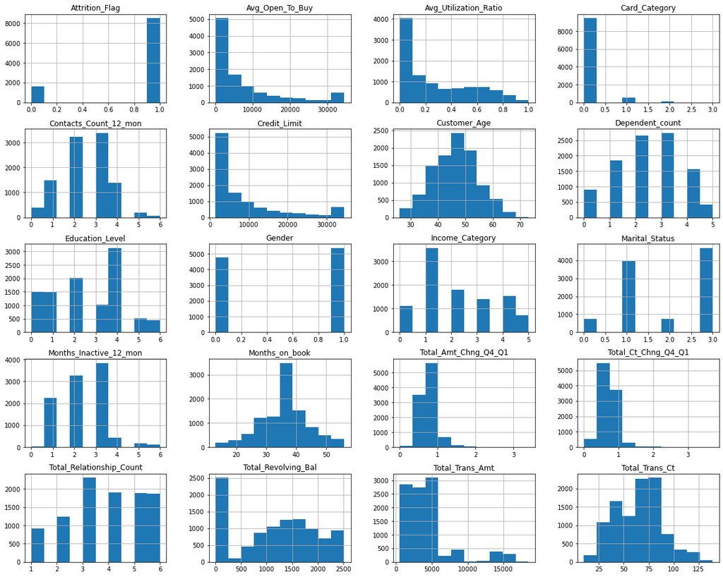

```python
plt.figure(figsize=(15,5))
cols = list(data)

print (cols)
data[cols].hist(stacked=False, bins=10, figsize=(20,40), layout=(12,4));
```

#### Notes from univariate analysis

- there are some variables that are skewed to the right:
  - Avg Open to Buy
  - Avg Utilization Ratio
  - Card category
  - Credit Limit
  - Total Amt CHng Q4 Q1
  - Total Trans Amt

These variables will not be transformed to account for real life differences in these amounts between customers

#### Bivariate Analysis

```python
data.corr()
```

|  | Attrition_Flag | Customer_Age | Gender | Dependent_count | Education_Level | Marital_Status | Income_Category | Card_Category | Months_on_book | Total_Relationship_Count | Months_Inactive_12_mon | Contacts_Count_12_mon | Credit_Limit | Total_Revolving_Bal | Avg_Open_To_Buy | Total_Amt_Chng_Q4_Q1 | Total_Trans_Amt | Total_Trans_Ct | Total_Ct_Chng_Q4_Q1 | Avg_Utilization_Ratio |
| --- | --- | --- | --- | --- | --- | --- | --- | --- | --- | --- | --- | --- | --- | --- | --- | --- | --- | --- | --- | --- |
| Attrition_Flag | 1.000000 | -0.018203 | -0.037272 | -0.018991 | -0.008796 | 0.024117 | 0.013577 | -0.002354 | -0.013687 | 0.150005 | -0.152449 | -0.204491 | 0.023873 | 0.263053 | 0.000285 | 0.131063 | 0.168598 | 0.371403 | 0.290054 | 0.178410 |
| Customer_Age | -0.018203 | 1.000000 | 0.017312 | -0.122254 | -0.002369 | 0.040298 | 0.023508 | -0.018235 | 0.788912 | -0.010931 | 0.054361 | -0.018452 | 0.002476 | 0.014780 | 0.001151 | -0.062042 | -0.046446 | -0.067097 | -0.012143 | 0.007114 |
| Gender | -0.037272 | 0.017312 | 1.000000 | -0.004563 | 0.005087 | -0.006491 | -0.786608 | -0.080093 | 0.006728 | -0.003157 | 0.011163 | -0.039987 | -0.420806 | -0.029658 | -0.418059 | -0.026712 | -0.024890 | 0.067454 | 0.005800 | 0.257851 |
| Dependent_count | -0.018991 | -0.122254 | -0.004563 | 1.000000 | 0.000472 | 0.004839 | 0.066278 | 0.030469 | -0.103062 | -0.039076 | -0.010768 | -0.040505 | 0.068065 | -0.002688 | 0.068291 | -0.035439 | 0.025046 | 0.049912 | 0.011087 | -0.037135 |
| Education_Level | -0.008796 | -0.002369 | 0.005087 | 0.000472 | 1.000000 | 0.015478 | -0.011677 | 0.014989 | 0.006613 | 0.000766 | 0.005761 | -0.006280 | -0.002354 | -0.006800 | -0.001743 | -0.010040 | -0.007460 | -0.004307 | -0.016692 | -0.001849 |
| Marital_Status | 0.024117 | 0.040298 | -0.006491 | 0.004839 | 0.015478 | 1.000000 | 0.017770 | -0.052296 | 0.030598 | 0.020427 | -0.004915 | 0.001780 | -0.053580 | 0.036352 | -0.056828 | 0.050805 | -0.062698 | -0.116268 | 0.008999 | 0.046623 |
| Income_Category | 0.013577 | 0.023508 | -0.786608 | 0.066278 | -0.011677 | 0.017770 | 1.000000 | 0.077326 | 0.022122 | -0.003202 | -0.016310 | 0.023113 | 0.475972 | 0.034718 | 0.472760 | 0.011352 | 0.019651 | -0.054569 | -0.012657 | -0.246476 |
| Card_Category | -0.002354 | -0.018235 | -0.080093 | 0.030469 | 0.014989 | -0.052296 | 0.077326 | 1.000000 | -0.012535 | -0.094077 | -0.014629 | -0.000442 | 0.492446 | 0.026304 | 0.489985 | 0.007385 | 0.196003 | 0.134275 | -0.007261 | -0.198711 |
| Months_on_book | -0.013687 | 0.788912 | 0.006728 | -0.103062 | 0.006613 | 0.030598 | 0.022122 | -0.012535 | 1.000000 | -0.009203 | 0.074164 | -0.010774 | 0.007507 | 0.008623 | 0.006732 | -0.048959 | -0.038591 | -0.049819 | -0.014072 | -0.007541 |
| Total_Relationship_Count | 0.150005 | -0.010931 | -0.003157 | -0.039076 | 0.000766 | 0.020427 | -0.003202 | -0.094077 | -0.009203 | 1.000000 | -0.003675 | 0.055203 | -0.071386 | 0.013726 | -0.072601 | 0.050119 | -0.347229 | -0.241891 | 0.040831 | 0.067663 |
| Months_Inactive_12_mon | -0.152449 | 0.054361 | 0.011163 | -0.010768 | 0.005761 | -0.004915 | -0.016310 | -0.014629 | 0.074164 | -0.003675 | 1.000000 | 0.029493 | -0.020394 | -0.042210 | -0.016605 | -0.032247 | -0.036982 | -0.042787 | -0.038989 | -0.007503 |
| Contacts_Count_12_mon | -0.204491 | -0.018452 | -0.039987 | -0.040505 | -0.006280 | 0.001780 | 0.023113 | -0.000442 | -0.010774 | 0.055203 | 0.029493 | 1.000000 | 0.020817 | -0.053913 | 0.025646 | -0.024445 | -0.112774 | -0.152213 | -0.094997 | -0.055471 |
| Credit_Limit | 0.023873 | 0.002476 | -0.420806 | 0.068065 | -0.002354 | -0.053580 | 0.475972 | 0.492446 | 0.007507 | -0.071386 | -0.020394 | 0.020817 | 1.000000 | 0.042493 | 0.995981 | 0.012813 | 0.171730 | 0.075927 | -0.002020 | -0.482965 |
| Total_Revolving_Bal | 0.263053 | 0.014780 | -0.029658 | -0.002688 | -0.006800 | 0.036352 | 0.034718 | 0.026304 | 0.008623 | 0.013726 | -0.042210 | -0.053913 | 0.042493 | 1.000000 | -0.047167 | 0.058174 | 0.064370 | 0.056060 | 0.089861 | 0.624022 |
| Avg_Open_To_Buy | 0.000285 | 0.001151 | -0.418059 | 0.068291 | -0.001743 | -0.056828 | 0.472760 | 0.489985 | 0.006732 | -0.072601 | -0.016605 | 0.025646 | 0.995981 | -0.047167 | 1.000000 | 0.007595 | 0.165923 | 0.070885 | -0.010076 | -0.538808 |
| Total_Amt_Chng_Q4_Q1 | 0.131063 | -0.062042 | -0.026712 | -0.035439 | -0.010040 | 0.050805 | 0.011352 | 0.007385 | -0.048959 | 0.050119 | -0.032247 | -0.024445 | 0.012813 | 0.058174 | 0.007595 | 1.000000 | 0.039678 | 0.005469 | 0.384189 | 0.035235 |
| Total_Trans_Amt | 0.168598 | -0.046446 | -0.024890 | 0.025046 | -0.007460 | -0.062698 | 0.019651 | 0.196003 | -0.038591 | -0.347229 | -0.036982 | -0.112774 | 0.171730 | 0.064370 | 0.165923 | 0.039678 | 1.000000 | 0.807192 | 0.085581 | -0.083034 |
| Total_Trans_Ct | 0.371403 | -0.067097 | 0.067454 | 0.049912 | -0.004307 | -0.116268 | -0.054569 | 0.134275 | -0.049819 | -0.241891 | -0.042787 | -0.152213 | 0.075927 | 0.056060 | 0.070885 | 0.005469 | 0.807192 | 1.000000 | 0.112324 | 0.002838 |
| Total_Ct_Chng_Q4_Q1 | 0.290054 | -0.012143 | 0.005800 | 0.011087 | -0.016692 | 0.008999 | -0.012657 | -0.007261 | -0.014072 | 0.040831 | -0.038989 | -0.094997 | -0.002020 | 0.089861 | -0.010076 | 0.384189 | 0.085581 | 0.112324 | 1.000000 | 0.074143 |
| Avg_Utilization_Ratio | 0.178410 | 0.007114 | 0.257851 | -0.037135 | -0.001849 | 0.046623 | -0.246476 | -0.198711 | -0.007541 | 0.067663 | -0.007503 | -0.055471 | -0.482965 | 0.624022 | -0.538808 | 0.035235 | -0.083034 | 0.002838 | 0.074143 | 1.000000 |

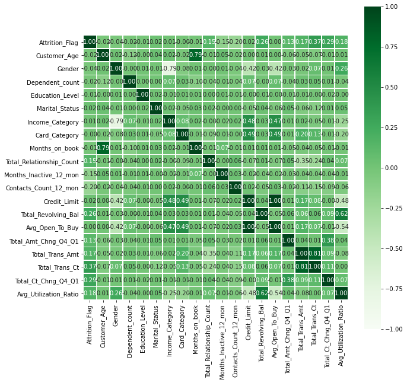

```python
plt.subplots(figsize=(10,10))
sns.heatmap(data.corr(),cmap='Greens',annot=True, fmt=".2f", vmin=-1, vmax=1, center= 0, square=True, linewidths=.7)
```

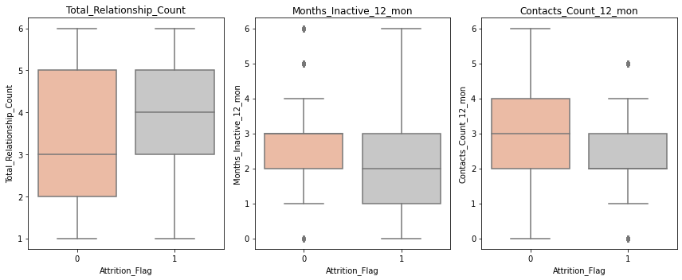

```python
cols = data[['Total_Relationship_Count', 'Months_Inactive_12_mon', 'Contacts_Count_12_mon']].columns.tolist()
plt.figure(figsize=(12,5))

for i, variable in enumerate(cols):
                     plt.subplot(1,3,i+1)
                     sns.boxplot(data['Attrition_Flag'],data[variable],palette="RdGy")
                     plt.tight_layout()
                     plt.title(variable)
plt.show()
```

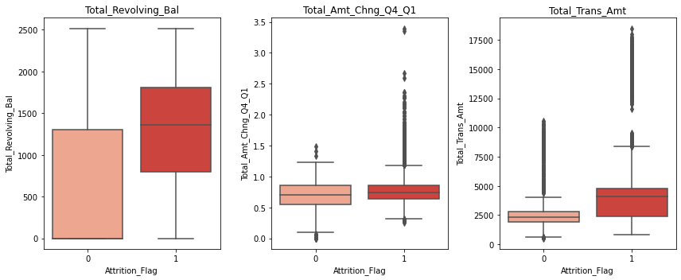

```python
cols = data[['Total_Revolving_Bal', 'Total_Amt_Chng_Q4_Q1', 'Total_Trans_Amt']].columns.tolist()
plt.figure(figsize=(12,5))

for i, variable in enumerate(cols):
                     plt.subplot(1,3,i+1)
                     sns.boxplot(data['Attrition_Flag'],data[variable],palette="Reds")
                     plt.tight_layout()
                     plt.title(variable)
plt.show()
```

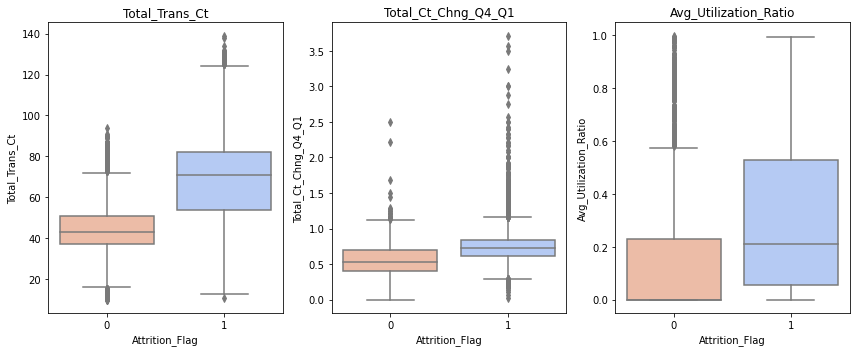

```python
cols = data[['Total_Trans_Ct', 'Total_Ct_Chng_Q4_Q1', 'Avg_Utilization_Ratio']].columns.tolist()
plt.figure(figsize=(12,5))

for i, variable in enumerate(cols):
                     plt.subplot(1,3,i+1)
                     sns.boxplot(data['Attrition_Flag'],data[variable],palette="coolwarm_r")
                     plt.tight_layout()
                     plt.title(variable)
plt.show()
```